# Microsoft Capstone: DAT102x: Predicting Heart Disease Mortality

Christohper Fraher

```r
## Load required packages
if("pacman" %in% rownames(installed.packages()) == FALSE) {
  install.packages("pacman")
}
library(pacman)
pacman::p_load(tidyverse, here, lubridate, caret, randomForest, RANN, jtools, doSNOW, plotly, corrplot, mice, VIM, lime)
```

```r
## Set up environment variables
rm(list=ls())
# Global prediction model
#project.preProcPredictImputeValues <- NULL
```

```r
# Function cleans up data, creates dummy vars, and returns imputated information
project.function_prepare_data <- function(project.modified_dataset, project.outcomecolumn = FALSE, project.outcomecolumn_name = NULL) {
# Convert values to factors

project.modified_dataset <- project.modified_dataset %>% mutate(area__rucc = as.factor(area__rucc),
                                                                area__urban_influence = as.factor(area__urban_influence),
                                                                econ__economic_typology = as.factor(econ__economic_typology),
                                                                yr = as.factor(yr))
# Feature generation
#Break area__rucc down to simply metro and not metro
project.modified_dataset$area__rucc__metro <- as.logical(project.modified_dataset$area__rucc %in%
  c("Metro - Counties in metro areas of 1 million population or more",
    "Metro - Counties in metro areas of 250,000 to 1 million population",
    "Metro - Counties in metro areas of fewer than 250,000 population"))
# Create an 18-64 window
project.modified_dataset$demo__pct_between_18_and_65 <- 1 - project.modified_dataset$demo__pct_below_18_years_of_age - project.modified_dataset$demo__pct_aged_65_years_and_older
# Convert to Log
#project.modified_dataset$health__pop_per_dentist <- log(project.modified_dataset$health__pop_per_dentist)
#project.modified_dataset$health__pop_per_primary_care_physician <- log(project.modified_dataset$health__pop_per_primary_care_physician)
project.modified_dataset
}
# Select the Data
project.function_select_data <- function(project.modified_dataset, project.outcomecolumn = FALSE, project.outcomecolumn_name = NULL) {

project.outcomecolumn_data <- NULL
if(project.outcomecolumn) {
  project.outcomecolumn_data <- project.modified_dataset %>% select("row_id", project.outcomecolumn_name)
}
project.modified_dataset <- project.modified_dataset %>% select("row_id",
                                                                # AREA
                                                                "area__rucc",
                                                                #"area__rucc__metro",
                                                                "area__urban_influence",

                                                                # ECON
                                                                "econ__economic_typology",

                                                                "econ__pct_civilian_labor", # Tableau - *Civilian Labor
                                                                "econ__pct_unemployment", # Tableau - *Unemployment
                                                                "econ__pct_uninsured_adults", # Tableau - *Uninsured Adults
                                                                "econ__pct_uninsured_children", # Tableau - ??? * Uninsured Children

                                                                # HEALTH
                                                                "health__pct_adult_obesity", # Tableau - Adult Obesity
                                                                "health__pct_diabetes", # Tableau - Diabetes
                                                                "health__pct_low_birthweight", # Not including not a direct influence
                                                                "health__pct_adult_smoking", # Tableau - Smoking
                                                                #"health__pct_excessive_drinking", # 30% missing data
                                                                "health__pct_physical_inacticity", # Tableau - *Inactivity
                                                                "health__air_pollution_particulate_matter", # Tebleau - *Pollution
                                                                #"health__homicides_per_100k", # Not heart disease
                                                                #"health__motor_vehicle_crash_deaths_per_100k", # Not heart disease
                                                                #"health__pop_per_dentist", # Not including since it is not pcp
                                                                "health__pop_per_primary_care_physician", #Tableau - *PCP Per Capita 1 & 2

                                                                # DEMO
                                                                "demo__pct_female", # Tableau - *Female
                                                                "demo__pct_below_18_years_of_age", # Tableau - *Under18
                                                                "demo__pct_between_18_and_65",
                                                                "demo__pct_aged_65_years_and_older", # Tableau - *Over 65
                                                                "demo__pct_hispanic", # Tableau - *Race/Eth
                                                                "demo__pct_non_hispanic_african_american", # Tableau - *Race/Eth
                                                                "demo__pct_non_hispanic_white", # Tableau - *Race/Eth
                                                                "demo__pct_asian", # Tableau - *Race/Eth
                                                                "demo__pct_american_indian_or_alaskan_native", # Tableau - *Race/Eth


                                                                "demo__pct_adults_less_than_a_high_school_diploma", # Tableau - *Education and Heart Disease
                                                                "demo__pct_adults_with_high_school_diploma", # Tableau - *Education and Heart Disease
                                                                "demo__pct_adults_with_some_college", # Tableau - *Education and Heart Disease
                                                                "demo__pct_adults_bachelors_or_higher", # Tableau - *Education and Heart Disease


                                                                #"demo__birth_rate_per_1k", # Confound
                                                                "demo__death_rate_per_1k"#, # Confound


                                                                #"yr" # Tableau - Removed Tableau - *Deaths by Area_Rucc by Year
                                                                )
if(project.outcomecolumn) {
  project.modified_dataset <- project.modified_dataset %>% inner_join(project.outcomecolumn_data, by = "row_id")
}
project.modified_dataset

}
# Impute the Data or Return Complete cases only
project.function_handle_missing_data <- function(project.modified_dataset, use_process = "impute", project.outcomecolumn = FALSE, project.outcomecolumn_name = NULL) {

if(use_process == "impute") {
project.values_imputed <- NULL
# Impute with MICE (Builds 5 models)
if(project.outcomecolumn) {
  project.values_imputed <- mice(project.modified_dataset, m=1, maxit = 50, method = 'sample', seed = 500, exclude = c('row_id', project.outcomecolumn_name), print = FALSE)

}
else {
  project.values_imputed <- mice(project.modified_dataset, m=1, maxit = 50, method = 'sample', seed = 500, exclude = c('row_id'), print = FALSE)
}
results <- project.values_imputed
}
  else if(use_process == "complete") {
    results <- project.modified_dataset[complete.cases(project.modified_dataset),]
  }

  results

}
```

```r
## Load the training dataset
project.training_values <- read_csv("Data/train_values.csv")
project.training_labels <- read_csv("Data/train_labels.csv")
## Convert level data to factors
project.training_values2 <- project.training_values %>% mutate(area__rucc = as.factor(area__rucc), area__urban_influence = as.factor(area__urban_influence), econ__economic_typology = as.factor(econ__economic_typology), yr = as.factor(yr))
```

```
 Variables sorted by number of missings:
```

| Variable | Count |
| --- | --- |
| health__homicides_per_100k | 0.6150719199 |
| health__pct_excessive_drinking | 0.3058161351 |
| health__pct_adult_smoking | 0.1450906817 |
| health__motor_vehicle_crash_deaths_per_100k | 0.1303939962 |
| health__pop_per_dentist | 0.0762976861 |
| health__pop_per_primary_care_physician | 0.0719199500 |
| health__pct_low_birthweight | 0.0569105691 |
| health__air_pollution_particulate_matter | 0.0087554722 |
| econ__pct_uninsured_adults | 0.0006253909 |
| econ__pct_uninsured_children | 0.0006253909 |

[output cut: 24 more lines]

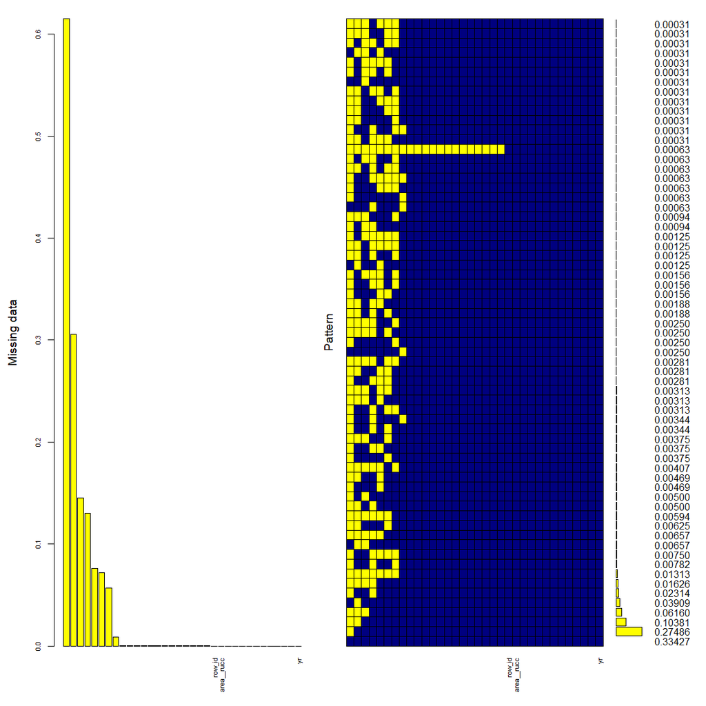

```r
#md.pattern(project.pattern)
project.mice_plot <- aggr(project.training_values, col=c('navyblue','yellow'),
                    numbers=TRUE, sortVars=TRUE, only.miss= TRUE,
                    labels=names(project.training_values), cex.axis=.7,
                    gap=3, ylab=c("Missing data","Pattern"))
```

```r
## Merge labels with values
project.training_values3 <- project.training_values2 %>% inner_join(project.training_labels, by = "row_id")
```

```r
## Get the summary data
## Summary
summary(project.training_values3)
```

```
     row_id                                                                                             area__rucc
 Min.   :   0   Nonmetro - Urban population of 2,500 to 19,999, adjacent to a metro area                     :608
 1st Qu.:1504   Nonmetro - Completely rural or less than 2,500 urban population, not adjacent to a metro area:484
 Median :3114   Metro - Counties in metro areas of 1 million population or more                              :436
 Mean   :3117   Nonmetro - Urban population of 2,500 to 19,999, not adjacent to a metro area                 :418
 3rd Qu.:4725   Metro - Counties in metro areas of 250,000 to 1 million population                           :370
 Max.   :6276   Metro - Counties in metro areas of fewer than 250,000 population                             :322
                (Other)                                                                                      :560
                                                                            area__urban_influence
 Small-in a metro area with fewer than 1 million residents                             :692
 Large-in a metro area with at least 1 million residents or more                       :436
 Noncore adjacent to a small metro with town of at least 2,500 residents               :346
 Micropolitan adjacent to a small metro area                                           :262
 Micropolitan not adjacent to a metro area                                             :254
 Noncore adjacent to micro area and does not contain a town of at least 2,500 residents:210
 (Other)                                                                               :998
                       econ__economic_typology econ__pct_civilian_labor econ__pct_unemployment econ__pct_uninsured_adults
 Farm-dependent                    : 482       Min.   :0.2070           Min.   :0.0100         Min.   :0.0460
 Federal/State government-dependent: 390       1st Qu.:0.4200           1st Qu.:0.0440         1st Qu.:0.1660
 Manufacturing-dependent           : 494       Median :0.4680           Median :0.0570         Median :0.2160
 Mining-dependent                  : 254       Mean   :0.4672           Mean   :0.0597         Mean   :0.2175
 Nonspecialized                    :1266       3rd Qu.:0.5140           3rd Qu.:0.0720         3rd Qu.:0.2610
 Recreation                        : 312       Max.   :1.0000           Max.   :0.2480         Max.   :0.4960
                                                                                               NA's   :2
 econ__pct_uninsured_children demo__pct_female demo__pct_below_18_years_of_age demo__pct_aged_65_years_and_older
 Min.   :0.01200              Min.   :0.2780   Min.   :0.0920                  Min.   :0.045
 1st Qu.:0.05700              1st Qu.:0.4930   1st Qu.:0.2060                  1st Qu.:0.141
 Median :0.07700              Median :0.5030   Median :0.2260                  Median :0.167
 Mean   :0.08607              Mean   :0.4988   Mean   :0.2277                  Mean   :0.170
 3rd Qu.:0.10600              3rd Qu.:0.5120   3rd Qu.:0.2460                  3rd Qu.:0.195
 Max.   :0.28100              Max.   :0.5730   Max.   :0.4170                  Max.   :0.346
 NA's   :2                    NA's   :2        NA's   :2                       NA's   :2
 demo__pct_hispanic demo__pct_non_hispanic_african_american demo__pct_non_hispanic_white
 Min.   :0.00000    Min.   :0.00000                         Min.   :0.0530
 1st Qu.:0.01900    1st Qu.:0.00600                         1st Qu.:0.6490
 Median :0.03500    Median :0.02200                         Median :0.8530
 Mean   :0.09021    Mean   :0.09105                         Mean   :0.7700
 3rd Qu.:0.08700    3rd Qu.:0.09600                         3rd Qu.:0.9363
 Max.   :0.93200    Max.   :0.85800                         Max.   :0.9900
 NA's   :2          NA's   :2                               NA's   :2
```

[output cut: 33 more lines]

```
 Min.   : 7.00                            Min.   :-0.400             Min.   :  3.14
 1st Qu.:10.00                            1st Qu.: 2.620             1st Qu.: 13.49
 Median :12.00                            Median : 4.700             Median : 19.63
 Mean   :11.63                            Mean   : 5.947             Mean   : 21.13
 3rd Qu.:13.00                            3rd Qu.: 7.890             3rd Qu.: 26.49
 Max.   :15.00                            Max.   :50.490             Max.   :110.45
 NA's   :28                               NA's   :1967               NA's   :417
 health__pop_per_dentist health__pop_per_primary_care_physician yr       heart_disease_mortality_per_100k
 Min.   :  339           Min.   :  189                          a:1599   Min.   :109.0
 1st Qu.: 1812           1st Qu.: 1420                          b:1599   1st Qu.:237.0
 Median : 2690           Median : 1999                                   Median :275.0
 Mean   : 3431           Mean   : 2551                                   Mean   :279.4
 3rd Qu.: 4090           3rd Qu.: 2859                                   3rd Qu.:317.0
 Max.   :28130           Max.   :23399                                   Max.   :512.0
 NA's   :244             NA's   :230
```

```r
## Mean / SD
mean(project.training_values3$heart_disease_mortality_per_100k, na.rm = T)
```

```
[1] 279.3693
```

```r
sd(project.training_values3$heart_disease_mortality_per_100k, na.rm = T)
```

```
[1] 58.95334
```

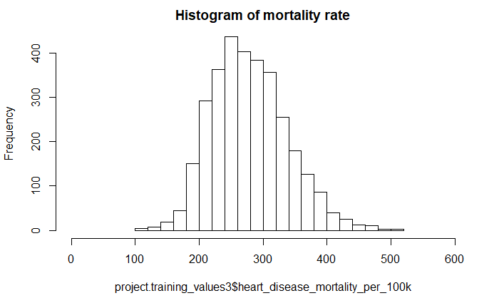

```r
## Graph the data
## Look at distribution of mortality
hist(project.training_values3$heart_disease_mortality_per_100k, breaks = 20, xlim = c(0, 600), main = "Histogram of mortality rate")
```

```r
## Median breakdown by Rural Urban Community Codes
## Metro
project.training_values3 %>% filter(as.integer(area__rucc) %in% c(1:4), !is.na(heart_disease_mortality_per_100k)) %>% summarise(median = median(heart_disease_mortality_per_100k))
```

| median |
| --- |
| 264 |

```r
## Non-metro
project.training_values3 %>% filter(!as.integer(area__rucc) %in% c(1:4), !is.na(heart_disease_mortality_per_100k)) %>% summarise(median = median(heart_disease_mortality_per_100k))
```

| median |
| --- |
| 283 |

It is shown here that the median mortality rates per 100k are lower in metro areas vs non-metro areas by a rate of less than 100 deaths per 100k.

```r
## Is there a correlation between birth rate and heart disease mortatility rate
cor(project.training_values3$demo__birth_rate_per_1k, project.training_values3$heart_disease_mortality_per_100k)
```

```
[1] 0.1421763
```

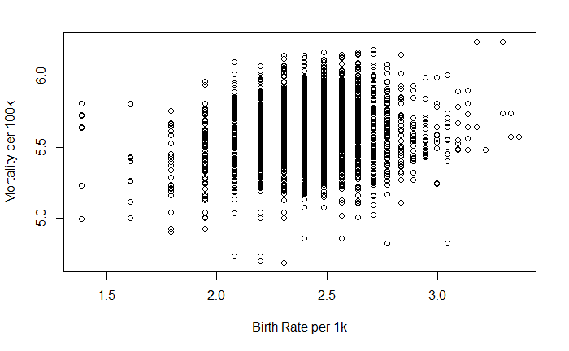

```r
plot(log(project.training_values3$demo__birth_rate_per_1k), log(project.training_values3$heart_disease_mortality_per_100k), xlab = "Birth Rate per 1k", ylab = "Mortality per 100k")
```

It would appear there is not a strong or obvious correlation between heart rate and heart disease mortality.

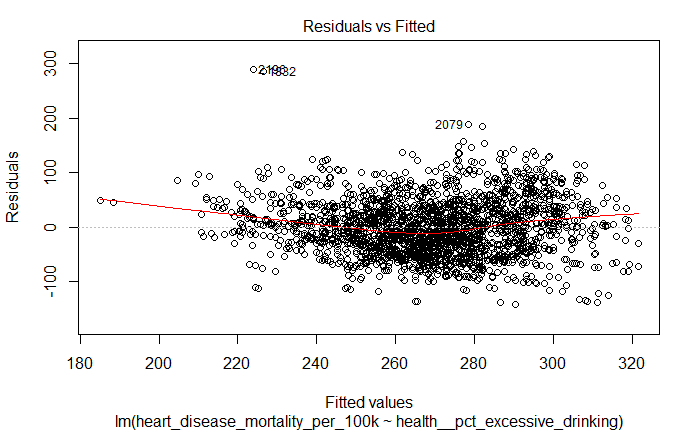

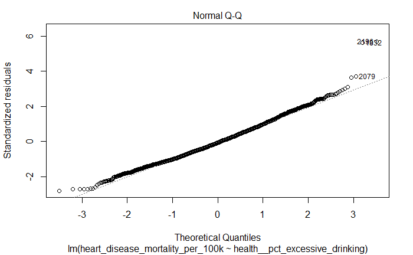

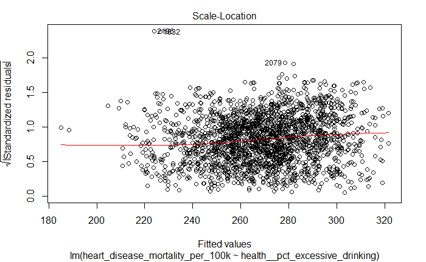

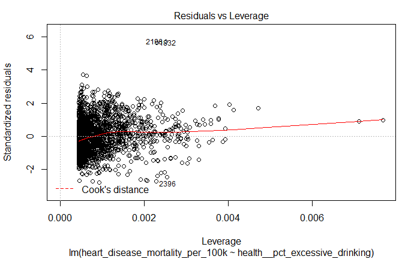

```r
# Build a linear model for Excessive Drinking vs Hear Disease Mortality
project.model_drink <- lm(heart_disease_mortality_per_100k ~ health__pct_excessive_drinking, project.training_values3)
# Plot the linear regression to check assumptions
plot(project.model_drink)
```

For additional help, the website https://data.library.virginia.edu/diagnostic-plots/ discusses how to review plots for linear regression.

The four assumptions checked here do hold for a linear regression on the Excessive Drinking vs Heart Disease Mortality model.

### Residuals vs Fitted:

The data points do not appear to indicate any noticeable patterns, and all data points remain balanced around 0.

### Scale-Location:

Homoscedasticity, equal variance, holds as the data points appear to spread evenly along the 0 line.

### Residuals vs Leverage:

Finally, no values appear to fall within a Cook’s distance, which would indicate exclusion of specific outliers would directly influence the regression.

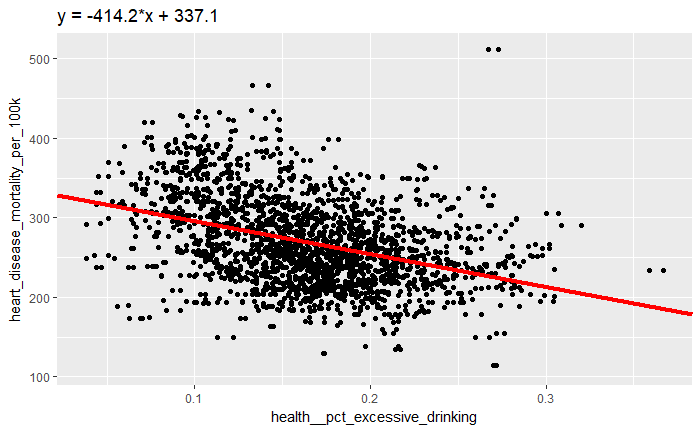

```r
# Equation of the line
eq = paste0("y = ", round(project.model_drink$coefficients[2],1), "*x + ", round(project.model_drink$coefficients[1],1))
# Plot the points and overlay the linear model
ggplot(data = project.training_values3, aes(x = health__pct_excessive_drinking, y = heart_disease_mortality_per_100k)) + geom_point() + geom_abline(intercept = project.model_drink$coefficients["(Intercept)"], slope = project.model_drink$coefficients["health__pct_excessive_drinking"], color = "red", size = 1.5) +   ggtitle(eq)
```

```r
summary(project.model_drink)
```

```
Call:
lm(formula = heart_disease_mortality_per_100k ~ health__pct_excessive_drinking,
    data = project.training_values3)

Residuals:
     Min       1Q   Median       3Q      Max
-141.306  -35.240   -3.185   32.298  287.958

Coefficients:
                               Estimate Std. Error t value Pr(>|t|)
(Intercept)                     337.106      3.666   91.96   <2e-16 ***
health__pct_excessive_drinking -414.153     21.264  -19.48   <2e-16 ***
---
Signif. codes:  0 ‘***’ 0.001 ‘**’ 0.01 ‘*’ 0.05 ‘.’ 0.1 ‘ ’ 1

Residual standard error: 50.56 on 2218 degrees of freedom
  (978 observations deleted due to missingness)
Multiple R-squared:  0.1461,    Adjusted R-squared:  0.1457
F-statistic: 379.4 on 1 and 2218 DF,  p-value: < 2.2e-16
```

### Evaluation

The regression indicates that there is a significant negative correlation with excessive drinking to hear disease mortality (p < 0.05).

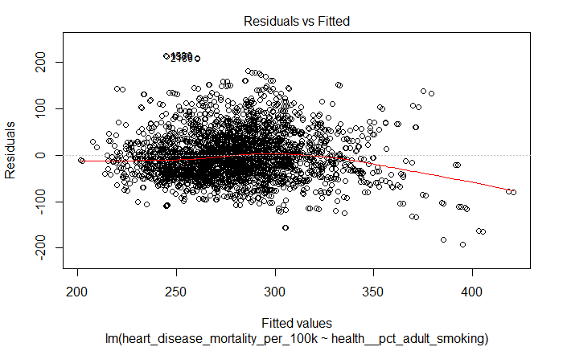

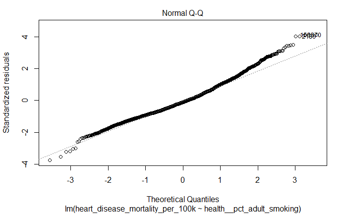

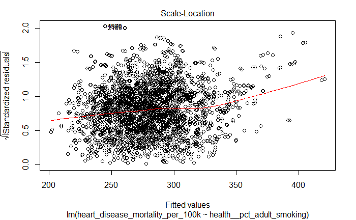

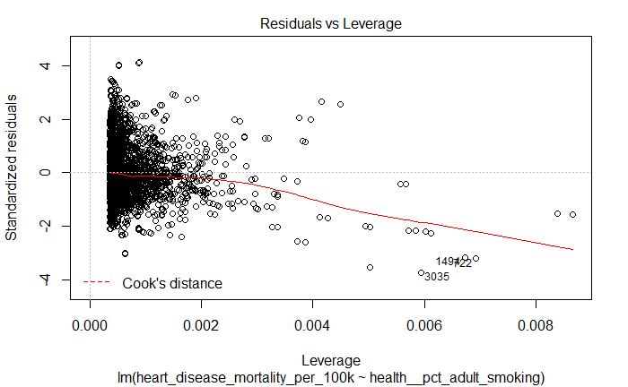

```r
# Build model for Smoking vs Heart Disease Mortatality
project.model_smoking <- lm(heart_disease_mortality_per_100k ~ health__pct_adult_smoking, project.training_values3)
# Plot the linear regression to check assumptions
plot(project.model_smoking)
```

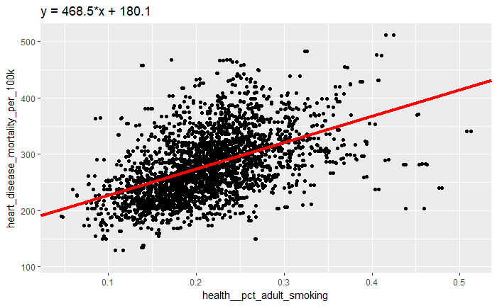

```r
# Equation of the line
eq_smoking = paste0("y = ", round(project.model_smoking$coefficients[2],1), "*x + ", round(project.model_smoking$coefficients[1],1))
# Plot the points and overlay the linear model
coeff_smoking = coefficients(project.model_smoking)
ggplot(data = project.training_values3, aes(x = health__pct_adult_smoking, y = heart_disease_mortality_per_100k)) + geom_point() + geom_abline(intercept = coeff_smoking["(Intercept)"], slope = coeff_smoking["health__pct_adult_smoking"], color = "red", size = 1.5) + ggtitle(eq_smoking)
```

```r
summary(project.model_smoking)
```

```
Call:
lm(formula = heart_disease_mortality_per_100k ~ health__pct_adult_smoking,
    data = project.training_values3)

Residuals:
     Min       1Q   Median       3Q      Max
-192.145  -35.574   -5.642   29.824  212.257

Coefficients:
                          Estimate Std. Error t value Pr(>|t|)
(Intercept)                180.084      3.485   51.68   <2e-16 ***
health__pct_adult_smoking  468.542     15.649   29.94   <2e-16 ***
---
Signif. codes:  0 ‘***’ 0.001 ‘**’ 0.01 ‘*’ 0.05 ‘.’ 0.1 ‘ ’ 1

Residual standard error: 51.45 on 2732 degrees of freedom
  (464 observations deleted due to missingness)
Multiple R-squared:  0.2471,    Adjusted R-squared:  0.2468
F-statistic: 896.5 on 1 and 2732 DF,  p-value: < 2.2e-16
```

A linear model of Adult Smoking vs Heart Disease Mortality indicate a significant positive correlation (p < 0.05).

```r
# Metro
project.training_values3 %>% filter(demo__pct_aged_65_years_and_older >= .2, str_detect(area__rucc, "^Metro")) %>% summarise(mean = mean(heart_disease_mortality_per_100k), median = median(heart_disease_mortality_per_100k), min = min(heart_disease_mortality_per_100k), max = max(heart_disease_mortality_per_100k))
```

| mean | median | min | max |
| --- | --- | --- | --- |
| 249.7903 | 251.5 | 175 | 359 |

```r
project.training_values3 %>% filter(demo__pct_aged_65_years_and_older < .2, str_detect(area__rucc, "^Metro")) %>% summarise(mean = mean(heart_disease_mortality_per_100k), median = median(heart_disease_mortality_per_100k), min = min(heart_disease_mortality_per_100k), max = max(heart_disease_mortality_per_100k))
```

| mean | median | min | max |
| --- | --- | --- | --- |
| 267.1454 | 263 | 151 | 409 |

```r
# Non-metro
project.training_values3 %>% filter(demo__pct_aged_65_years_and_older >= .2, str_detect(area__rucc, "^Non")) %>% summarise(mean = mean(heart_disease_mortality_per_100k), median = median(heart_disease_mortality_per_100k), min = min(heart_disease_mortality_per_100k), max = max(heart_disease_mortality_per_100k))
```

| mean | median | min | max |
| --- | --- | --- | --- |
| 260.5788 | 254 | 109 | 449 |

```r
project.training_values3 %>% filter(demo__pct_aged_65_years_and_older < .2, str_detect(area__rucc, "^Non")) %>% summarise(mean = mean(heart_disease_mortality_per_100k), median = median(heart_disease_mortality_per_100k), min = min(heart_disease_mortality_per_100k), max = max(heart_disease_mortality_per_100k))
```

| mean | median | min | max |
| --- | --- | --- | --- |
| 297.8589 | 294 | 114 | 512 |

```r
# Both Metro and Non metro, compare heard disease mortality between relatively older populations and those who are not
project.training_values3 %>% filter(demo__pct_aged_65_years_and_older >= .2) %>% summarise(mean = mean(heart_disease_mortality_per_100k), median = median(heart_disease_mortality_per_100k), min = min(heart_disease_mortality_per_100k), max = max(heart_disease_mortality_per_100k))
```

| mean | median | min | max |
| --- | --- | --- | --- |
| 259.6009 | 254 | 109 | 449 |

```r
project.training_values3 %>% filter(demo__pct_aged_65_years_and_older < .2) %>% summarise(mean = mean(heart_disease_mortality_per_100k), median = median(heart_disease_mortality_per_100k), min = min(heart_disease_mortality_per_100k), max = max(heart_disease_mortality_per_100k))
```

| mean | median | min | max |
| --- | --- | --- | --- |
| 284.8252 | 281 | 114 | 512 |

One discovery, when you impute a dataset, make sure to not include the row_id. Including this will force it to be part of the analysis forcing it to be normalized along with the rest of the dataset.

### Correlations

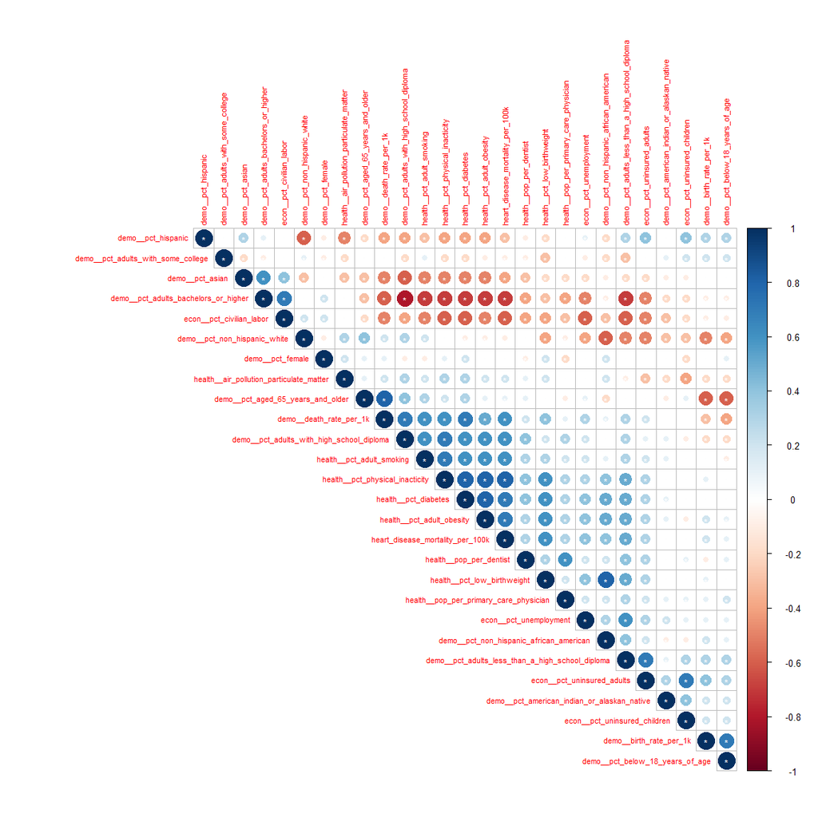

```r
project.training_values3_numeric <- project.training_values3[, sapply(project.training_values3, is.numeric)]
project.training_values3_numeric_complete <- project.training_values3_numeric[complete.cases(project.training_values3_numeric),]
project.training_values3_numeric_complete <- project.training_values3_numeric_complete %>% select(-one_of("row_id", "health__homicides_per_100k", "health__pct_excessive_drinking", "health__motor_vehicle_crash_deaths_per_100k"))
project.training_values3_numeric_corr <- round(cor(project.training_values3_numeric_complete, use = "complete.obs", method="pearson"), 1)
project.training_values3_numeric_corr_res <- cor.mtest(project.training_values3_numeric_complete, conf.level = 0.95)
corrplot(project.training_values3_numeric_corr, p.mat = project.training_values3_numeric_corr_res$p, method = "circle", type = "upper",
         sig.level = c(.001), pch.cex = .9, tl.cex = 0.7,
         insig = "label_sig", pch.col = "white", order = "AOE")
```

### Removing Values

The problem asks for a model that can be used to help predict the number of deaths from heart disease, of which many of the factors in this dataset could help indicate. There are those features though that a medical doctor, or subject matter expert may say do not have a medical signifcance to the prediction. Having such variables in the training model may in fact cause overfitting. The number of births may have some relation, if for example we were to run a linear regression on the rate of heart disease looking at rate of births alone, it would come out as a positve correlation, by a factor of 3 for every 1,000 births (see plot below). Does this mean that for every child born, more people are likely to die from heart disease? More than likely not, but that is not saying there is absolutely no releation, but this variable may overfit the model based on the data though.

- health__homicides_per_100k - Deaths by homicide per 100,000 population (National Center for Health Statistics)
- health__motor_vehicle_crash_deaths_per_100k - Deaths by motor vehicle crash per 100,000 population (National Center for Health Statistics)
- demo__birth_rate_per_1k - Births per 1,000 of population (US Census Population Estimates)
- demo__death_rate_per_1k - Deaths per 1,000 of population (US Census Population Estimates)

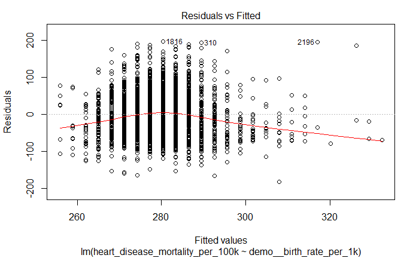

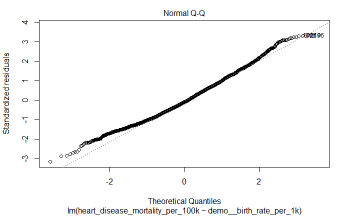

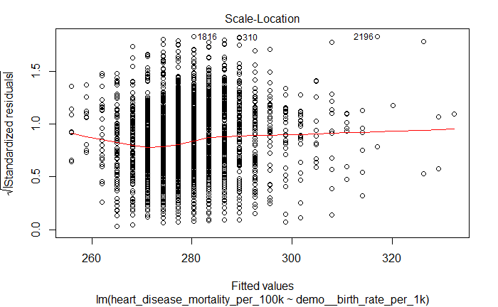

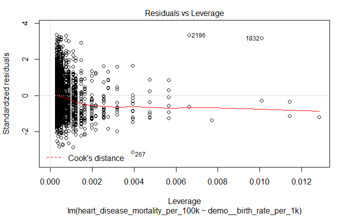

```r
project.model_births <- lm(heart_disease_mortality_per_100k ~ demo__birth_rate_per_1k, project.training_values3)
plot(project.model_births)
```

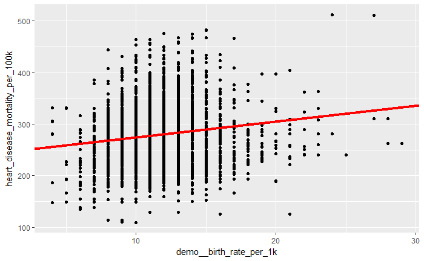

```r
# Plot the points and overlay the linear model
coeff_births = coefficients(project.model_births)
ggplot(data = project.training_values3, aes(x = demo__birth_rate_per_1k, y = heart_disease_mortality_per_100k)) + geom_point() + geom_abline(intercept = coeff_births["(Intercept)"], slope = coeff_births["demo__birth_rate_per_1k"], color = "red", size = 1.5)
```

```r
project.training_values4 <- project.training_values3
```

### Analyzing Missing Data

A brief analysis of each feature in the training dataset indicates most of the values exist, many of which having all data or missing under 10% of the total values. After calculating and ordering based on percent missing, 4 values indicate more than 10% of the data as NA: health__pct_excessive_drinking and health__pct_adult_smoking, about 30% and 15% respectively. Earlier in the analysis it was indicated that excessive drinking had a negative correlation with the number of heart disease related deaths. This fact is counter intuitive to data collected by the American Heart Association. According to the AHA, drinking can increase levels of chemicals associated with cardiovascular risk factors [link](http://www.heart.org/HEARTORG/HealthyLiving/HealthyEating/Nutrition/Alcohol-and-Heart-Health_UCM_305173_Article.jsp#.W0aiD9JKj7w). It is possible that having one-third of the data missing may be masking the true correlation, and imputing that large of a dataset may bias the model toward higher drinking indicates better heart health.

In turn, the next largest group with missing values is adult smoking at 15%. In this case 85% of the data is available, and it does show the expected positive correlation with the number of heart disease deaths. In this case we will use an imputation method on this variable.

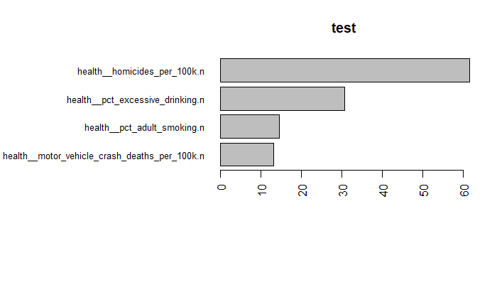

```r
project.missing_data <- t(as.data.frame(sapply(project.training_values4, function(x, records) round(sum(is.na(x))/records * 100, digits = 2), count(project.training_values4))))
project.missing_data <- cbind(project.missing_data, rownames(project.missing_data))
project.missing_data <- as.data.frame(project.missing_data, optional = FALSE, make.names = TRUE)
project.missing_data$V1 <- as.numeric(as.character(project.missing_data$V1))
project.missing_data <- project.missing_data[order(project.missing_data$V1),]
project.missing_data_top10 <- project.missing_data %>% filter(V1 >= 10)
# Fitting Labels
par(las=2) # make label text perpendicular to axis
par(mar=c(10,16,4,2)) # increase y-axis margin.
barplot(project.missing_data_top10$V1, main="test", names.arg = project.missing_data_top10$V2, horiz = TRUE, cex.names=0.8)
```

```r
project.training_values5 <- project.training_values4
```

Missing data can be indicative of other possible factors in the outcome, such as there may be a possible correlation between more rural areas and a missing health related variable due to a lack of an organization tracking a data point. Or maybe the data was not valid and was not included in the dataset. Either way, the missing values may be helpful to track even after imputation. Therefore, for every feature that has missing data, a corresponding feature will be engineered to track this.

A review of possible correlations in the data indicate possible confounding when looking at education with respect to the percent of the civilian labor force along with unemployment rates with respect to the same variable. Highly correlated variables include: demo__pct_adults_less_than_a_high_school_diploma, demo__pct_adults_bachelors_or_higher, and econ__pct_civilian_labor.

```r
# Build a correlation matrix for all but categorical variables
project.correlation_matrix <- cor(project.training_values5[,5:26])
# find attributes that are highly corrected (ideally >0.75)
highlyCorrelated <- findCorrelation(project.correlation_matrix, cutoff = 0.5)
# print indexes of highly correlated attributes
print(highlyCorrelated)
```

```
[1] 16 13  1
```

```r
sapply(highlyCorrelated, function(x) colnames(project.correlation_matrix)[x])
```

```
[1] "demo__pct_adults_bachelors_or_higher"             "demo__pct_adults_less_than_a_high_school_diploma"
[3] "econ__pct_civilian_labor"
```

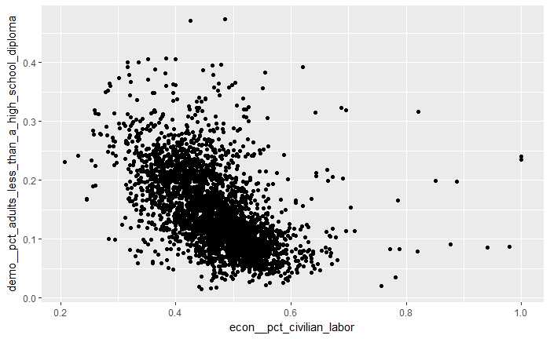

```r
ggplot(project.training_values5, aes(econ__pct_civilian_labor, demo__pct_adults_less_than_a_high_school_diploma)) + geom_point()
```

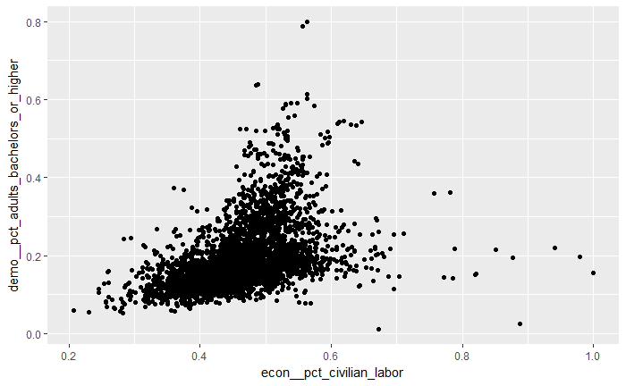

```r
ggplot(project.training_values5, aes(econ__pct_civilian_labor, demo__pct_adults_bachelors_or_higher)) + geom_point()
```

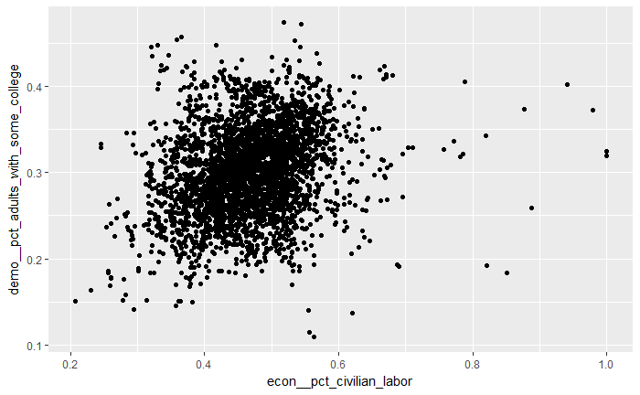

```r
ggplot(project.training_values5, aes(econ__pct_civilian_labor, demo__pct_adults_with_some_college)) + geom_point()
```

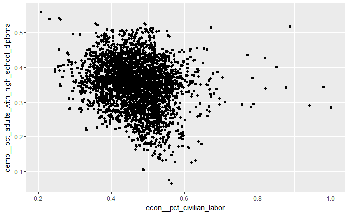

```r
ggplot(project.training_values5, aes(econ__pct_civilian_labor, demo__pct_adults_with_high_school_diploma)) + geom_point()
```

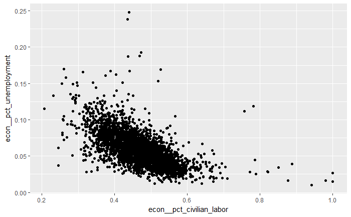

```r
ggplot(project.training_values5, aes(econ__pct_civilian_labor, econ__pct_unemployment)) + geom_point()
```

Now split the data into prediction and test.

```r
project.prepare_split <- project.training_values %>% inner_join(project.training_labels, by = "row_id")
seed = 123
set.seed(seed)
#project.prepare_split <- project.prepare_split[complete.cases(project.prepare_split),]
indexes <- createDataPartition(project.prepare_split$heart_disease_mortality_per_100k,
                               times = 1,
                               p = 0.8,
                               list = FALSE)
project.official_train_dirty <- project.prepare_split[indexes,]
project.official_test_dirty <- project.prepare_split[-indexes,]
```

```r
project.official_train <- project.function_handle_missing_data(project.official_train,
                                                               use_process = "complete",
                                                               project.outcomecolumn = TRUE,
                                                               project.outcomecolumn_name = "heart_disease_mortality_per_100k")
```

[output not shown]

After initially building the ML models, they did not provide a very successful prediction rate. RMSE is a more precise measurement than accuracy, so it will be used to evaluate these.

```r
# Use repeated cross validation
#control <- trainControl(method="repeatedcv", number = 10, repeats = 5, savePredictions = TRUE)
control <- trainControl(method="cv", number = 10, savePredictions = TRUE)
p_process <- c( "center", "scale", "nzv", "BoxCox")  #"nzv", , "pca", , "BoxCox"
metric <- "RMSE"
rf_grid = expand.grid(mtry = 1:13)
# Train a model
```

```r
cl <- makeCluster(5, type = "SOCK")
registerDoSNOW(cl)
```

```r
#set.seed(seed)
#project.ml_model_lm <- train(heart_disease_mortality_per_100k ~ ., data = project.official_train, method = "lm", metric = metric, preProcess = p_process, trControl = control)
```

```r
# kNN
#set.seed(seed)
#project.ml_model_knn <- train(heart_disease_mortality_per_100k ~ ., data = project.official_train, method = "knn", metric = metric, preProcess = p_process, trControl = control, tuneLength = 10)
```

```r
# Logistic Regression
#set.seed(seed)
#project.ml_model_glm <- train(heart_disease_mortality_per_100k ~ ., data = project.official_train, method = "glm", metric = metric, preProcess = p_process, trControl = control)
```

```r
# Random Forest
#set.seed(seed)
#project.ml_model_rf <- train(heart_disease_mortality_per_100k ~ . -row_id, data = project.official_train, method="rf", metric = metric, preProcess = p_process, trControl = control, ntrees = 500)
```

```r
# GLMNET
#set.seed(seed)
#project.ml_model_glmnet <- train(heart_disease_mortality_per_100k ~ . -row_id, data = project.official_train, method="glmnet", metric = metric, preProcess = p_process, trControl = control)
```

```r
#set.seed(seed)
#project.ml_model_ranger <- train(heart_disease_mortality_per_100k ~ ., data = project.official_train, method="ranger", metric = metric, preProcess = p_process, trControl = control, tuneGrid = rf_grid)
```

```r
#set.seed(seed)
#project.ml_model_pcaNNet <- train(heart_disease_mortality_per_100k ~ . -row_id, data = project.official_train, method="pcaNNet", metric = metric, preProcess = p_process, trControl = control)
```

```r
#set.seed(seed)
#project.ml_model_bayesglm <- train(heart_disease_mortality_per_100k ~ . -row_id, data = project.official_train, method="bayesglm", metric = metric, preProcess = p_process, trControl = control)
```

```r
#set.seed(seed)
#project.ml_model_bridge <- train(heart_disease_mortality_per_100k ~ . -row_id, data = project.official_train, method="bridge", metric = metric, preProcess = p_process, trControl = control)
```

```r
#set.seed(seed)
#project.ml_model_lmStepAIC <- train(heart_disease_mortality_per_100k ~ . -row_id, data = project.official_train, method="lmStepAIC", metric = metric, preProcess = p_process, trControl = control)
```

```r
# Stochastic Gradient Boosting (Generalized Boosted Modeling)
set.seed(seed)
project.ml_model_gbm <- train(heart_disease_mortality_per_100k ~ ., data = project.official_train, method="gbm", metric = metric, preProcess = p_process, trControl = control, verbose = FALSE)
```

```r
# Stochastic Gradient Boosting (Generalized Boosted Modeling)
set.seed(seed)
project.ml_model_gbm_5 <- train(heart_disease_mortality_per_100k ~ ., data = project.official_train, method="gbm", metric = metric, preProcess = p_process, trControl = control, tuneLength = 5, verbose = FALSE)
```

```r
# Stochastic Gradient Boosting (Generalized Boosted Modeling)
#set.seed(seed)
#project.ml_model_gbm_10 <- train(heart_disease_mortality_per_100k ~ ., data = project.official_train, method="gbm", metric = metric, preProcess = p_process, trControl = control, tuneLength = 10, verbose = FALSE)
```

```r
#set.seed(seed)
#project.ml_model_gbm_xgb <- train(heart_disease_mortality_per_100k ~ ., data = project.official_train, method="xgbTree", metric = metric, preProcess = p_process, trControl = control, tuneLength = 10, verbose = FALSE)
```

```r
#set.seed(seed)
#project.ml_model_baggedCART <- train(heart_disease_mortality_per_100k ~ .-row_id, data = project.official_train, method="treebag", metric = metric, preProcess = p_process, trControl = control)
```

```r
#set.seed(seed)
#project.ml_model_blassoAveraged <- train(heart_disease_mortality_per_100k ~ .-row_id, data = project.official_train, method="blassoAveraged", metric = metric, preProcess = p_process, trControl = control)
```

```r
#set.seed(seed)
#project.ml_model_gaussprLinear <- train(heart_disease_mortality_per_100k ~ ., data = project.official_train[,-1], method="gaussprLinear", metric = metric, preProcess = p_process, trControl = control)
```

```r
stopCluster(cl)
```

Had some great help from https://machinelearningmastery.com/evaluate-machine-learning-algorithms-with-r/ when starting to evaluate the models

```r
# Uses built in formula detection
results <- resamples(list(#lm_model = project.ml_model_lm,
                          #knn_model = project.ml_model_knn,
                          #glm_model = project.ml_model_glm,
                          #rf_model = project.ml_model_rf,
                          #glmnet_model = project.ml_model_glmnet,
                          gbm_model = project.ml_model_gbm,
                          gbm_5_model = project.ml_model_gbm_5
                          #gbm_10_model = project.ml_model_gbm_10
                          #gbm_xgb_model = project.ml_model_gbm_xgb
                          #ranger_model = project.ml_model_ranger#,
                          #ANFIS_model = project.ml_model_ANFIS,
                          #bayesglm = project.ml_model_bayesglm,
                          #blassoAvg = project.ml_model_blassoAveraged,
                          #gaussprLinear = project.ml_model_gaussprLinear
                          #baggedCART = project.ml_model_baggedCART
                          #pcaNNet_model = project.ml_model_pcaNNet
                          ))
summary(results)
```

```
Call:
summary.resamples(object = results)

Models: gbm_model, gbm_5_model
Number of resamples: 10

MAE
                Min.  1st Qu.   Median     Mean  3rd Qu.     Max. NA's
gbm_model   24.27979 24.74718 25.15551 25.23017 25.63698 26.80543    0
gbm_5_model 22.98640 23.20620 23.56460 23.79983 24.08358 25.44015    0

RMSE
                Min.  1st Qu.   Median     Mean  3rd Qu.     Max. NA's
gbm_model   31.06777 31.41771 32.64548 32.80661 34.07278 35.02617    0
gbm_5_model 29.39894 30.01674 31.13209 30.97340 31.96482 32.55198    0

Rsquared
                 Min.   1st Qu.    Median      Mean   3rd Qu.      Max. NA's
gbm_model   0.6686474 0.6813662 0.6878847 0.6960858 0.7063001 0.7375678    0
gbm_5_model 0.7065463 0.7143972 0.7266915 0.7293642 0.7424291 0.7569822    0
```

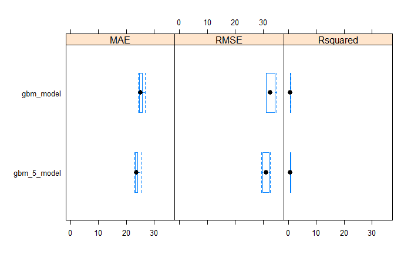

```r
# boxplot comparison
bwplot(results)
```

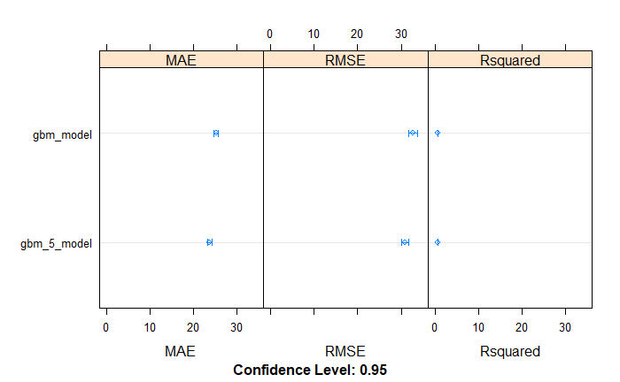

```r
# Dot-plot comparison
dotplot(results)
```

```r
project.explainer <- lime(project.official_train, project.ml_model_gbm)
#project.explanation <- explain(project.official_train, project.explainer, n_features = 2)
#plot_features(project.explanation, ncol = 1)
```

```r
project.model_to_use <- project.ml_model_gbm_5
# Testing
# Strip the outcomes
project.official_test_outcomes <- project.official_test_dirty %>% select(row_id, heart_disease_mortality_per_100k)
project.official_test <- project.function_prepare_data(project.official_test_dirty)
project.official_test <- project.function_select_data (project.official_test)
project.official_test <- project.function_handle_missing_data(project.official_test)
```

```
Number of logged events: 200
```

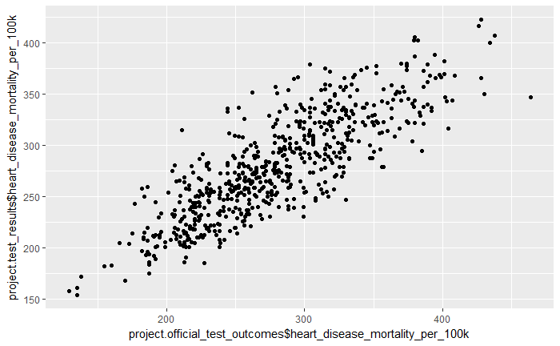

```r
project.offical_test_complete <- complete(project.official_test, 1)
project.test_predictions <- predict(project.model_to_use, project.offical_test_complete)
project.test_predictions <- round(project.test_predictions, 0)
project.test_results <- data.frame(row_id = project.offical_test_complete$row_id, heart_disease_mortality_per_100k = project.test_predictions)
qplot(project.official_test_outcomes$heart_disease_mortality_per_100k, project.test_results$heart_disease_mortality_per_100k)
```

```r
RMSE(project.official_test_outcomes$heart_disease_mortality_per_100k, project.test_results$heart_disease_mortality_per_100k)
```

```
[1] 31.54727
```

### Variable Influence

|  | var | rel.inf |
| --- | --- | --- |
| health__pct_physical_inacticity | health__pct_physical_inacticity | 18.28087670 |
| health__pct_diabetes | health__pct_diabetes | 15.19688451 |
| demo__pct_adults_less_than_a_high_school_diploma | demo__pct_adults_less_than_a_high_school_diploma | 12.52347145 |
| demo__death_rate_per_1k | demo__death_rate_per_1k | 6.38497838 |
| demo__pct_aged_65_years_and_older | demo__pct_aged_65_years_and_older | 5.07766981 |
| health__pct_adult_obesity | health__pct_adult_obesity | 4.88021485 |
| demo__pct_adults_bachelors_or_higher | demo__pct_adults_bachelors_or_higher | 4.14962638 |
| demo__pct_non_hispanic_african_american | demo__pct_non_hispanic_african_american | 3.22044940 |
| health__pct_low_birthweight | health__pct_low_birthweight | 3.12223815 |
| health__pct_adult_smoking | health__pct_adult_smoking | 3.05738319 |

[output cut: 35 more lines]

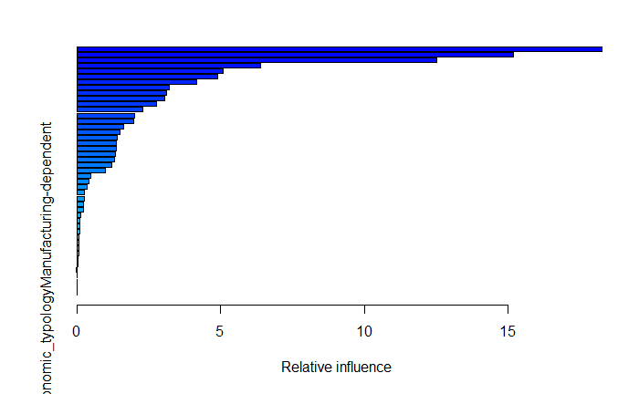

```r
summary(project.model_to_use)
```

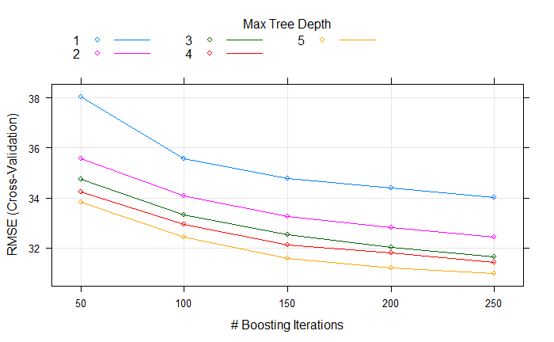

```r
plot(project.model_to_use)
```

```r
# Load the data
project.competition_values <- read_csv("Data/test_values.csv")
# Prepare the data
project.competition_values_prepared <- project.function_prepare_data(project.competition_values)
project.competition_values_prepared <- project.function_prepare_data(project.competition_values_prepared)
project.competition_values_prepared <- project.function_select_data (project.competition_values_prepared)
project.competition_values_prepared <- project.function_handle_missing_data(project.competition_values_prepared)
```

```
Number of logged events: 900
```

```r
# Get the completed dataset
project.competition_values_complete <- complete(project.competition_values_prepared, 1)
# Make predictions
project.competition_predictions <- predict(project.model_to_use, project.competition_values_complete)
# Round to integer values
project.competition_predictions <- round(project.competition_predictions, 0)
# Output the data
output <- data.frame(row_id = project.competition_values_complete$row_id, heart_disease_mortality_per_100k = project.competition_predictions)
write.csv(output, 'Results/FinalResults_62.csv', row.names = FALSE, na = "",  quote = FALSE)
```

After running through a few problems dealing with imputation, it was made clear that one must be careful not to include the row_id as a value in the process of imputation. Some methods of imputation normalize the data, which in turn normalizes the row_id and uses it in the calculation, starting the process off with poor training data and when run on the competition dataset, renders it useless.

### Key learning point: if you preprocess your training/test data a specific way, or impute a specific way, do the same with the datasets you will processing the finished ML model on.

```r
write.excel <- function(x,row.names=FALSE,col.names=TRUE,...) {
  write.table(x,"clipboard",sep="\t",row.names=row.names,col.names=col.names,...)
}

#write.excel(sapply(project.training_values[,-1], function(x) data.frame(Min = min(x, na.rm = TRUE), Max = max(x, na.rm = TRUE), Mean = mean(x, na.rm = TRUE),  StdDev = sd(x, na.rm = TRUE), Missing = sum(is.na(x)))), row.names = TRUE, col.names = TRUE)
```